# OMD multiscale comparison (cont'd from Sep 21)

Sangwon Hyun, Jacob Bien, and the Ocean Provinces working group

# Sinkhorn's algorithm

The Sinkhorn distance is an *approximation* to the Wasserstein's (Earthmover's) distance.

Given a cost matrix $M$ that encodes the distance between each of the points in the departure and destination, and the mass $r$ in the departure, and $c$ in the destination, optimal transport is:

$$d_M(\mathbf{r}, \mathbf{c}) = \min_{P\in U(\mathbf{r}, \mathbf{c})}\, \sum_{i,j}P_{ij}M_{ij}$$

From this nice blogpost https://michielstock.github.io/OptimalTransport/, the optimization problem is modified to:

$$d_M^\lambda(\mathbf{r}, \mathbf{c}) = \min_{P\in U(\mathbf{r}, \mathbf{c})}\, \sum_{i,j}P_{ij}M_{ij} - \frac{1}{\lambda}h(P)$$

whose penalty term

$$h(P) = -\sum_{i,j}P_{ij}\log P_{ij}$$

is the information entropy of P. One can increase the entropy by making the distribution more homogeneous.

The algorithm comes from observing that the optimum is of the form:

$$(P_\lambda^\star)_{ij} = \alpha_i\beta_j e^{-\lambda M_{ij}}$$

with $\alpha_i$ and $\beta_j$ that have to be determined such that the rows sum to $r$ and columns sum to $c$!

The algorithm is:

initialize: $P_\lambda = e^{-\lambda M}$

repeat

- scale the rows such that the row sums match r
- scale the columns such that the column sums match c

until convergence

We have so far been relying on the `transport` R package, which

- Handles images on grids well (but data needs to be on equally spaced row and column names).
- Handles coordinates on a map well.
- Algorithms used are hard to understand, and implemented piece-meal (some combinations are not possible to run e.g. 1st power of Euclidean distance). I got some hard-to-solve errors.
- Speed seems very fast for images (on grids)

Optimal distance on images (on grids) are handled well because they use a special algorithm that iterates from a coarser grid to a finer grid. From the package documentation:

"For larger problems it is advisable to use the multiscale version, which currently is only implemented for square pgrids in two dimensions. The algorithm proceeds then by coarsening the pgrid nscales-1 times, summarizing each time scmult^2 pixels into one larger pixels, and then solving the various transport problems starting from the coarsest and using each previous problem to compute a starting solution to the next finer problem. If returncoarse is TRUE, the coarser problems and their solutions are returned as well (revsimplex only)."

Now, using our own implementation is desirable because:

- We have full control over the variants of proble.
- We understand better the actual implementation (since we will have written it).
- There are even faster versions of the Sinkhorn we might be able to use. I've only written up the simplest version.
- If we accept some bias (by using lots of regularization), speed might be comparable to the `transport` package.
  - It seems there is some variance introduced as well, when using more regularization? This is a downside.
- More figures to describe this speed & bias tradeoff.

To add, I think I'd prefer to make my own plotting, instead of using the `transport` package's plot functions. This doesn't depend on using our own (e.g. Sinkhorn) implementation.

# Trying out Sinkhorn

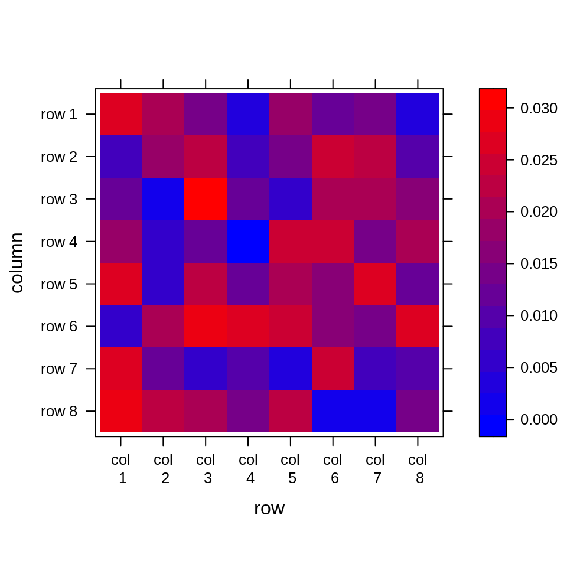

```r
## Setup
delta = 10
pp = 8
lambda = 10
costdiag = 10000

set.seed(0)
img1 = matrix(runif(pp^2), ncol=pp)
img2 = matrix(runif(pp^2), ncol=pp)
lower_half = (pp/2 + 1):(pp)
img2[lower_half, lower_half] = img2[lower_half, lower_half] + delta
img1 = img1/sum(img1)
img2 = img2/sum(img2)
drawmat_precise(img1)
```

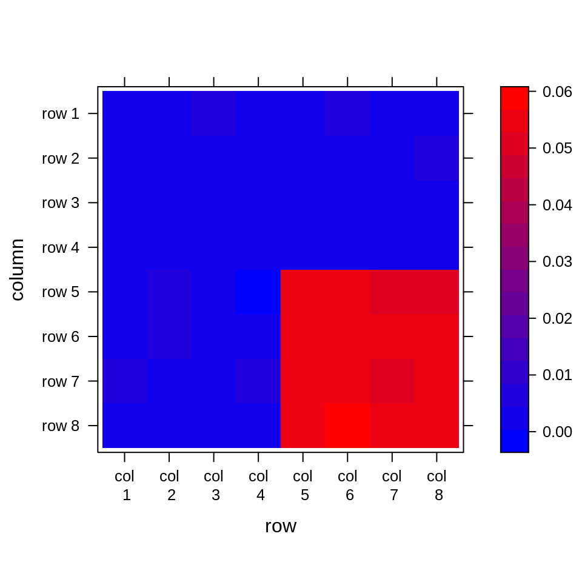

```r
drawmat_precise(img2)
```

```r
colnames(img1) = rownames(img1) = sapply(1:pp, toString)
colnames(img2) = rownames(img2) = sapply(1:pp, toString)

## Change format
dat1 = image_to_long_format(img1)
dat2 = image_to_long_format(img2)

## Make cost matrix
costm = form_cost_matrix(dat1)##^2
diag(costm) = costdiag

## Calculate sinkhorn
tm = proc.time()
sinkhorn_dist = sinkhorn(costm = costm,
                         invec = dat1 %>% pull(val),
                         outvec = dat2 %>% pull(val),
                         lambda = lambda,
                         eps = 0.00001) %>% .[["dist"]]
sinkhorn_time = (proc.time() - tm) %>% .["elapsed"] %>% unname()

tm <- proc.time()
res <- transport::transport(dat1 %>% pull(val),
                            dat2 %>% pull(val),
                            costm = costm)
transportR_dist = transport::wasserstein(dat1 %>% pull(val),
                                        dat2 %>% pull(val),
                                        costm = costm,
                                        tplan = res)
transportR_time = (proc.time() - tm) %>% .["elapsed"] %>% unname()

sinkhorn_dist %>% print()
```

```
## [1] 2.712993
```

```r
transportR_dist %>% print()
```

```
## [1] 2.6762
```

Now, running the simulation (using the same code from directly above):

```r
## Generate data
onesim <- function(lambda,
                   costdiag = 10000,
                   pp = 4,
                   nsim = 100,
                   delta = 10){

  info = sapply(1:nsim, function(iseed){
    set.seed(iseed)
    img1 = matrix(runif(pp^2), ncol=pp)
    img2 = matrix(runif(pp^2), ncol=pp)
    lower_half = (pp/2 + 1):(pp)
    img2[lower_half, lower_half] = img2[lower_half, lower_half] + delta
    img1 = img1/sum(img1)
    img2 = img2/sum(img2)
    colnames(img1) = rownames(img1) = sapply(1:pp, toString)
    colnames(img2) = rownames(img2) = sapply(1:pp, toString)

    ## Change format
    dat1 = image_to_long_format(img1)
    dat2 = image_to_long_format(img2)

    ## Make cost matrix
    costm = form_cost_matrix(dat1)##^2
    diag(costm) = costdiag

    ## Calculate sinkhorn
    tm = proc.time()
    sinkhorn_dist = sinkhorn(costm = costm,
                             invec = dat1 %>% pull(val),
                             outvec = dat2 %>% pull(val),
                             lambda = lambda,
                             eps = 0.00001) %>% .[["dist"]]
    sinkhorn_time = (proc.time() - tm) %>% .["elapsed"] %>% unname()

    tm <- proc.time()
    res <- transport::transport(dat1 %>% pull(val),
                                dat2 %>% pull(val),
                                costm = costm)
    transportR_dist = transport::wasserstein(dat1 %>% pull(val),
                                            dat2 %>% pull(val),
                                            costm = costm,
                                            tplan = res)
    transportR_time = (proc.time() - tm) %>% .["elapsed"] %>% unname()

    return(c(sinkhorn = sinkhorn_dist,
             transportR = transportR_dist,
             sinkhorn_time = sinkhorn_time,
             transportR_time = transportR_time))
  })
  return(t(info))
}
```

Running the simulation, for a range of lambda values `lams = c(0.1, 0.3, 0.5, 0.8, 1, 2, 5, 10, 20)`:

```r
lams = c(0.1, 0.3,  0.5, 0.8, 1, 2, 5, 10, 20)

## Run simulations
infolist = lapply(lams, function(lam){
  info = onesim(lambda = lam, pp=8)
}) %>% setNames(lams)
```

When we compare the OMDs of Sinkhorn distances to exact Wasserstein distances, we see that there's an induced bias for small values of `lambda`:

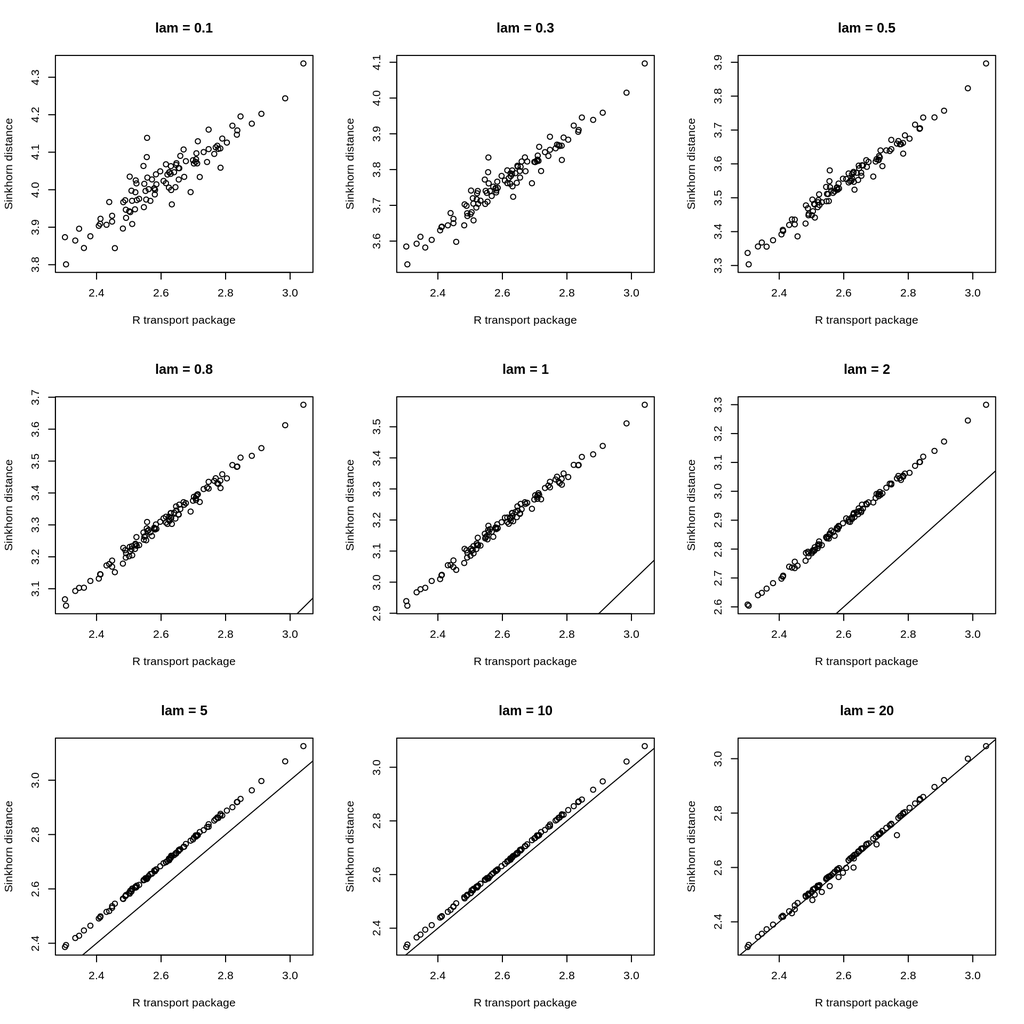

```r
## Make plots speeds
par(mfrow=c(3,3))
Map(function(info, lam){
  dists = info %>% as_tibble() %>% select(x=transportR, y=sinkhorn)
  plot(x=dists$x, y=dists$y, xlab = "R transport package", ylab = "Sinkhorn distance")
  abline(0,1)
  title(main = paste0("lam = ", lam))
}, infolist, lams) %>% invisible()
```

But for lower bias result, more computation is required:

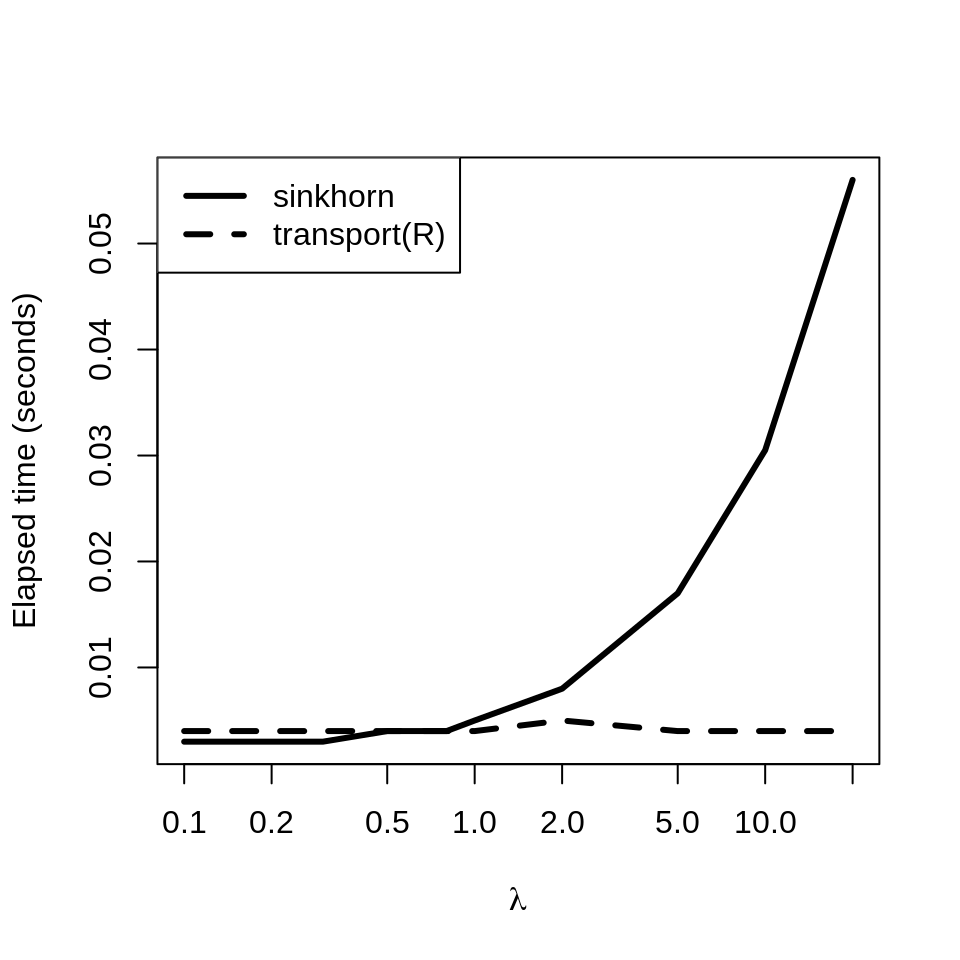

```r
## Get speeds
timeslist = infolist %>% lapply(., function(info){
  times = info %>% as_tibble() %>% select(contains("time")) %>% apply(.,2, median)
})
times = timeslist %>% do.call(rbind, .)
matplot(y = times,
        x = lams,
        type='l', lwd=3, lty=1:2, col="black",
        log = "x",
        ylab = "Elapsed time (seconds)",
        xlab = expression(lambda))
legend("topleft", lwd = 3, lty = 1:2, col="black", legend = c("sinkhorn", "transport(R)"))
```

```r
lams = c(0.1, 0.3,  0.5, 0.8, 1, 2, 5, 10, 20)
## pps = c(4,6,8,10,15,20,30,40,50)
pps = c(2,5,10,
        15,20,30)

list_of_infolist = mclapply(pps, function(pp){
  print(pp)
  infolist = mclapply(lams, function(lam){
    info = onesim(lambda = lam, pp = pp, nsim = 30)
  }, mc.cores = 8) %>% setNames(lams)
  return(infolist)
}, mc.cores = 1) %>% setNames(pps)

saveRDS(list_of_infolist, file = file.path(destin, "list_of_infolist.RDS"))
```

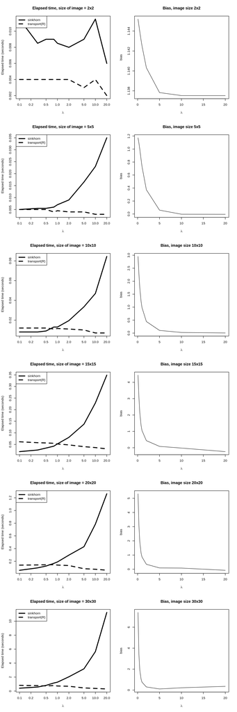

```r
list_of_infolist = readRDS(file = file.path(destin, "list_of_infolist.RDS"))
pps = c(2,5,10, 15,20,30)
par(mfrow=c(6,2))
for(pp in pps){

  ## Results from a pp x pp image
  infolist = list_of_infolist[[toString(pp)]]

  ## Plot the times
  timeslist = infolist %>% lapply(., function(info){
    times = info %>% as_tibble() %>% select(contains("time")) %>% apply(.,2, median)
  })
  times = timeslist %>% do.call(rbind, .)
  matplot(y = times,
          x = lams,
          type='l', lwd=3, lty=1:2, col="black",
          log = "x",
          ylab = "Elapsed time (seconds)",
          xlab = expression(lambda))
  legend("topleft", lwd = 3, lty = 1:2, col="black", legend = c("sinkhorn", "transport(R)"))
  title(main = paste0("Elapsed time, size of image = ", pp, "x", pp))

  ## Plot the intercepts, which kind of quantify the bias:
  intercepts = sapply(infolist, function(info){
    dists = info %>% as_tibble() %>% select(x=transportR, y=sinkhorn)
    intercept = lm(y~x, data=dists) %>% coef() %>% .["(Intercept)"]
    return(intercept)
  })
  plot(y=intercepts, x=lams, type='l', ylab = "bias", xlab = expression(lambda))
  title(main = paste0("Bias, image size ", pp, "x", pp))

  ## par(mfrow=c(3,3))
  ## Map(function(info, lam){
  ##   dists = info %>% as_tibble() %>% select(x=transportR, y=sinkhorn)
  ##   plot(x=dists$x, y=dists$y, xlab = "R transport package", ylab = "Sinkhorn distance")
  ##   abline(0,1)
  ##   title(main = paste0("lam = ", lam))
  ## }, infolist, lams) %>% invisible()
}
```

# Apply to simulated data

Let's examine coarsening vs. OMD again.

```r
make_plist <- function(type = 1, keep_at_original_res = FALSE){
  resol = 32
  d1 = matrix(runif(resol^2), ncol=resol)
  fac = 1
  if(type==2) d1 = d1 + Matrix::bdiag(matrix(rep(fac,64), nrow=8), diag(rep(0,24))) %>% as.matrix()
  rownames(d1) = colnames(d1) = c(1:resol) - 1

  ## Coarsen three times
  d2 = avg_coarsen(d1)
  d3 = avg_coarsen(d2)
  d4 = avg_coarsen(d3)

  ## Enlarge
  if(keep_at_original_res){
    d2 = d2 %>% enlarge()
    d3 = d3 %>% enlarge() %>% enlarge()
    d4 = d4 %>% enlarge() %>% enlarge() %>% enlarge()
    rownames(d4) = rownames(d3) = rownames(d2) = rownames(d1)
    colnames(d4) = colnames(d3) = colnames(d2) = colnames(d1)
  }

  ## Now, apply splitting
  p1 = d1 %>% make_pgrid()
  p2 = d2 %>% make_pgrid()
  p3 = d3 %>% make_pgrid()
  p4 = d3 %>% make_pgrid()
  return(list(p1=p1, p2=p2, p3=p3, p4=p4,
              d1=d1, d2=d2, d3=d3, d4=d4))
}
```

Taking 32 x 32 images and using a small block rised in the corner:

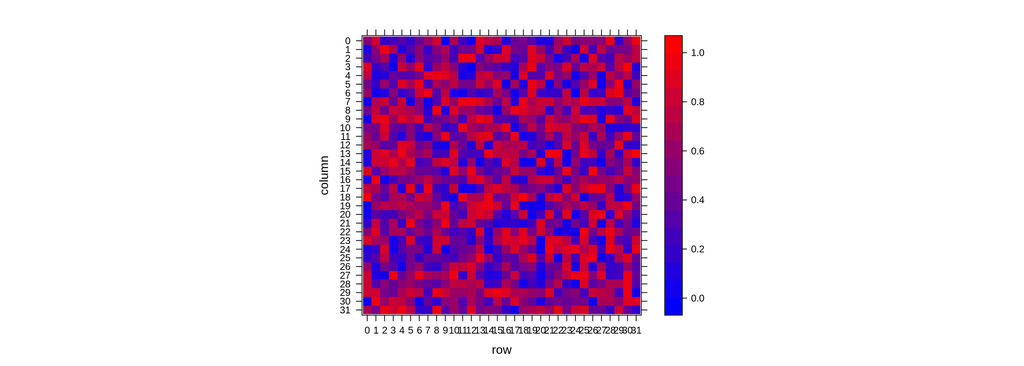

```r
plist1 = make_plist(type = 1, keep_at_original_res = FALSE)
plist2 = make_plist(type = 2, keep_at_original_res = FALSE)
drawmat_precise(plist1$d1)
```

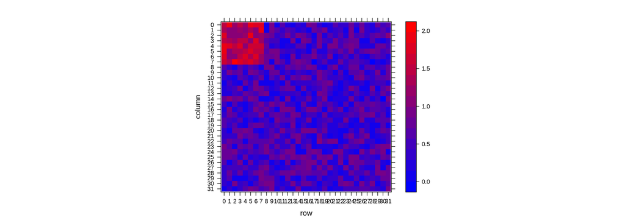

```r
drawmat_precise(plist2$d1)
```

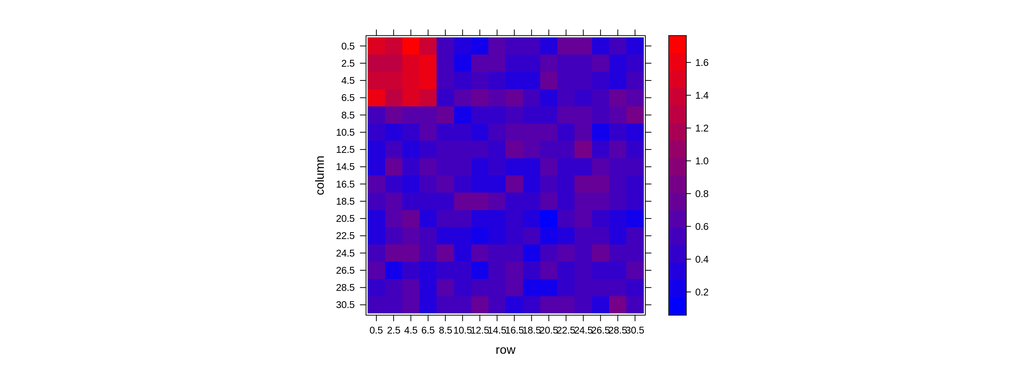

```r
drawmat_precise(plist2$d2)
```

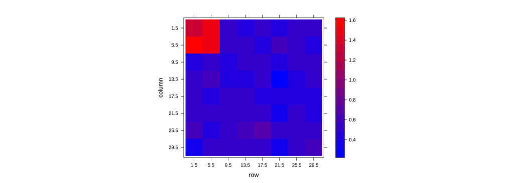

```r
drawmat_precise(plist2$d3)
```

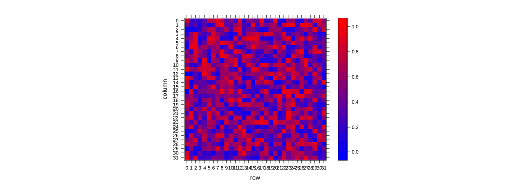

```r
plist1 = make_plist(type = 1, keep_at_original_res = TRUE)
plist2 = make_plist(type = 2, keep_at_original_res = TRUE)
drawmat_precise(plist1$d1)
```

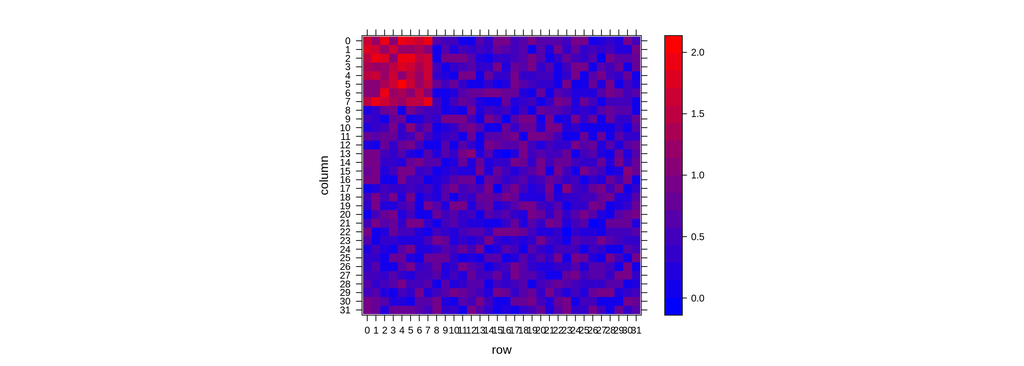

```r
drawmat_precise(plist2$d1)
```

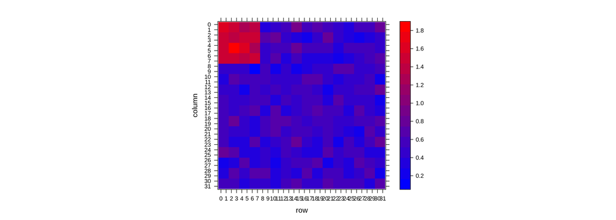

```r
drawmat_precise(plist2$d2)
```

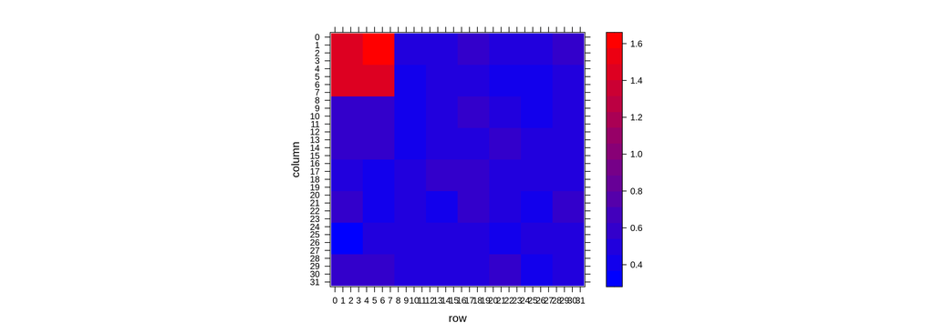

```r
drawmat_precise(plist2$d3)
```

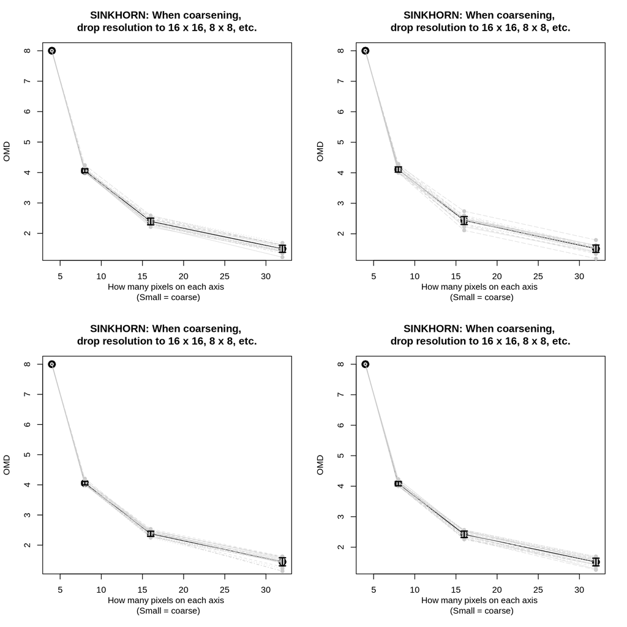

```r
par(mfrow = c(2,2))
for(transportR in c(FALSE, TRUE)){
  for(keep_res in c(FALSE, TRUE)){
    transportR = FALSE
    keep_res = FALSE

    nsim = 24
    distlist = mclapply(1:nsim, function(isim){

      plist1 = make_plist(type = 1, keep_at_original_res = keep_res)
      plist2 = make_plist(type = 2, keep_at_original_res = keep_res)

      dists = c()
      for(ii in 1:4){
        if(transportR){
          res <- transport::transport(plist1[[ii]], plist2[[ii]], p = 2, method = "aha")
          dist = transport::wasserstein(plist1[[ii]], plist2[[ii]], p = 2, tplan = res)
        } else {

          d1 = plist1[[ii+4]]
          d2 = plist2[[ii+4]]
          d1 = d1/sum(d1)
          d2 = d2/sum(d2)
          dat1 = image_to_long_format(d1)
          dat2 = image_to_long_format(d2)

          ## Make cost matrix
          costm = form_cost_matrix(dat1)#^2
          diag(costm) = 1E6

          ## Calculate sinkhorn
          lambda = 10
          dist = sinkhorn(costm = costm,
                          invec = dat1 %>% pull(val),
                          outvec = dat2 %>% pull(val),
                          lambda = lambda,
                          eps = 0.00001) %>% .[["dist"]]
        }
        dists[ii] = dist
      }
      return(dists)
    }, mc.cores = 8)
    distmat = distlist %>% do.call(rbind, .)

    ## Make the OMD vs Resolution plots
    mns = distmat %>% apply(., 2, mean)
    sds = distmat %>% apply(., 2, sd)
    x = c(32, 16, 8, 4)
    plot(y=mns, x=x, ylim = range(mns-sds, mns+sds), pch = 16, cex=2, type='o',
         xlab = "How many pixels on each axis \n (Small = coarse)",
         ylab = "OMD")
    matpoints(y = t(distmat),
              x = x,
              type='o', pch=16, lwd=0.5,
              col = 'grey80')
    arrows(x, mns-sds, x, mns+sds, length=0.05, angle=90, code=3, lwd=2)

    main = ifelse(keep_res,
                  "When coarsening, \nkeep original resolution 32 x 32",
                  "When coarsening, \ndrop resolution to 16 x 16, 8 x 8, etc.")
    main = ifelse(transportR, main, paste0("SINKHORN: ", main))
    title(main = main)
  }
}
```

(In the above plot, ignore the left-hand-side Sinkhorn plot, whose resulting distances seem to be odd. Note to self: At the coarsest resolution `ii=4`, there seems to be some odd behavior going on; when the diagonal entries of `costm` are set equal to anything lower than 8, then the transport is equal to that value; when it's larger (up to 1E8, say), then the transport seems to be capped at 8.)